# Life Data Analysis Part I - Estimation of Failure Probabilities

A Non-parametric Approach

Tim-Gunnar Hensel

2019-01-29

This document presents non-parametric methods for estimating the failure probabilities of units and their presentation in interactive visualizations. A unit can be a single component, an assembly or an entire system.

## Introduction to Life Data Analysis

If the lifetime of a unit is considered to be a continuous random variable *T*, then the probability that a unit has failed by a certain point in time or a distance *t* is defined by its CDF *(cumulative distribution function)* *F(t)*.
$$P(T\leq t) = F(t)$$

In order to obtain an estimate of the cumulative failure probability for each observation $t_1, t_2, ..., t_n$ two approaches are possible.  
Using a parametric lifetime distribution requires that the underlying assumptions for the sample data are valid. If the distribution-specific assumptions are correct, the model parameters can be estimated and the CDF is computable. But if the required conditions could not be met, interpretations and derived conclusions are not reliable.  
A more general approach for the calculation of the cumulative failure probability is to use non-parametric statistical estimators $\hat{F}(t_1), \hat{F}(t_2), ..., \hat{F}(t_n)$. In comparison to a parametric distribution no general assumptions must be held. For non-parametric estimators, an ordered sample of size n is needed. Starting at 1, the ranks $i \in \{1, 2, ..., n \}$ are assigned to the ascending sorted sample values. Since there is a known relationship between ranks and corresponding ranking probabilities a CDF can be calculated.

But rank distributions are systematically skewed distributions and thus the median value instead of the expected value $E\left[F\left(t_i\right)\right] = \frac{i}{n + 1}$ is used for estimation [^1]. This skewness is visualized in *Figure 1*.

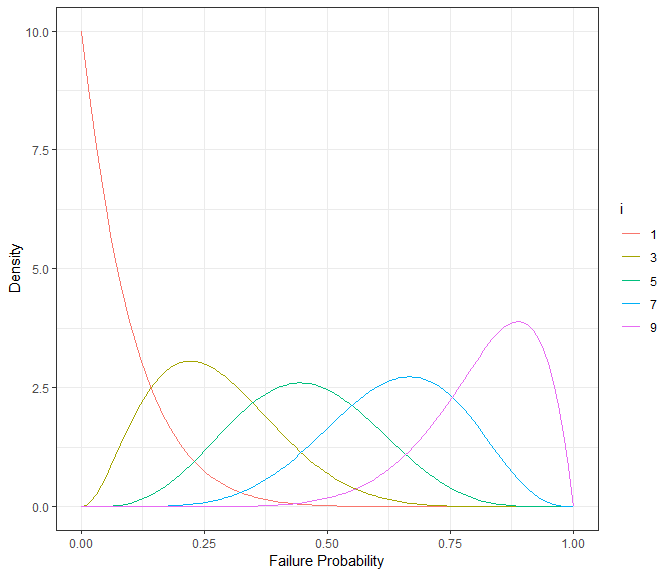

Figure 1: Densities for different ranks i in samples of size n = 10.

```r
library(tidyverse) # using dplyr manipulation functions and ggplot2

x <- seq(0, 1, length.out = 100) # CDF
n <- 10 # sample size
i <- c(1, 3, 5, 7, 9) # ranks
r <- n - i + 1 # inverse ranking

df_dens <- expand.grid(cdf = x, i = i) %>%
  mutate(n = n, r = n - i + 1, pdf = dbeta(x = x, shape1 = i, shape2 = r))

densplot <- ggplot(data = df_dens, aes(x = cdf, y = pdf, colour = as.factor(i))) +
  geom_line() +
  scale_colour_discrete(guide = guide_legend(title = "i")) +
  theme_bw() +
  labs(x = "Failure Probability", y = "Density")
densplot
```

### Failure Probability Estimation

In practice, a simplification for the calculation of the median value, also called median rank, is made. The formula of *Benard’s Approximation* is given by
$$\hat{F}(t_i) \approx \frac{i - 0,3}{n + 0,4}$$
and is described in *The Plotting of Observations on Probability Paper* [^2].

However, this equation only provides valid estimates for failure probabilities if all units in the sample are defectives (`mr_method()`).

In field data analysis, however, the sample mainly consists of intact units and only a small fraction of units failed. Units that have no damage at the point of analysis and also have not reached the operating time or mileage of units that have already failed, are potential candidates for future failures.  
As these, for example, still are likely to fail during a specific time span, like the guarantee period, the failure probability must be adjusted upwards by these potential candidates.

A commonly used method for correcting probabilities of (multiple) right censored data is Johnson’s method (`johnson_method()`). By this method, all units that fall into the period looked at are sorted in an ascending order of their operating time or mileage. If there are units that have not failed before the *i*-th failure, an adjusted rank for the *i*-th failure is formed. This correction takes the potential candidates into account and increases the rank number. In consequence, a higher rank leads to a higher failure probability. This can be seen in *Figure 1*.

The rank adjustment (`calculate_ranks()`) is calculated as follows:
$$j_i = j_{i-1} + x_i \cdot I_i, \;\; with \;\; j_0 = 0$$

Here, $j_ {i-1}$ is the adjusted rank of the previous failure, $x_i$ is the number of defectives at time/distance $t_i$ and $I_i$ is the increment that corrects the rank by the candidates.
$$I_i=\frac{(n+1)-j_{i-1}}{1+(n-n_i)}$$

The sample size is $n$ and $n_i$ is the number of units that have a lower operating time/mileage than the *i*-th unit. Once the adjusted ranks are calculated, the failure probabilities can be estimated according to *Benard’s Approximation*.

Other methods in `weibulltools` that can also handle (multiple) right censored data are the Kaplan-Meier estimator (`kaplan_method()`) and the Nelson-Aalen estimator (`nelson_method()`).

### Probability Plotting

After computing failure probabilities a method called *Probability Plotting* is applicable. It is a graphical *goodness of fit* technique that is used in assessing whether an assumed distribution is appropriate to model the sample data.

The axes of a probability plot are transformed in such a way that the CDF of a specified model is represented through a straight line (`plot_layout()`). If the plotted points (`plot_prob()`) fall on an approximately straight line it can be said that the chosen distribution is adequate.

The two-parameter Weibull distribution can be parameterized with $\eta$ and $\beta$ such that the CDF is characterized by the following equation:
$$F(t)=1-\exp\left[ -\left(\frac{t}{\eta}\right)^{\beta}\right]$$
Then a linearized version of the CDF is:
$$\log\left[-\log(1-F(t))\right] = \beta \cdot \log(t) - \beta \cdot \log(\eta)$$
This leads to the following transformations regarding the axes:

- Abscissa: $x = \log(t)$
- Ordinate: $y = \log\left[-\log(1-F(t))\right]$.

Another version of the Weibull CDF such that the distribution is part of the log-location-scale family with parameters $\mu$ and $\sigma$ is:
$$F(t)=\Phi_{SEV}\left(\frac{\log(t) - \mu}{\sigma}\right)$$
A linearized representation of this CDF is:
$$\Phi^{-1}_{SEV}\left(F(t)\right)=\frac{1}{\sigma} \cdot \log(t) - \frac{\mu}{\sigma}$$
This leads to the following transformations regarding the axes:

- Abscissa: $x = \log(t)$
- Ordinate: $y = \Phi^{-1}_{SEV}\left(F(t)\right)$, which is the quantile function of the SEV (*smallest extreme value*) distribution.

It can be easily seen that the parameters can be converted into each other. The corresponding equations are:

$$\beta = \frac{1}{\sigma} \;\; and$$
$$\eta = \exp\left(\mu\right).$$

## Data: shock

To apply the introduced methods of non-parametric failure probability estimation and probability plotting the `shock` data taken from `SPREDA` package is used. In this dataset kilometer-dependent problems that have occurred on shock absorbers are reported. In addition to failed items the dataset also contains non-defectives, so called *censored* observations.  
The data can be found in *Statistical Methods for Reliability Data* [^3].

```r
library(SPREDA) # for dataset shock
data(shock)
# generate random ids for units:
shock$id <- sample(c(letters, LETTERS), size = nrow(shock), replace = FALSE)

# using tibble for better print:
as_tibble(shock)
```

```
#> # A tibble: 38 x 4
#>    Distance Mode     Censor id
#>       <int> <fct>     <dbl> <chr>
#>  1     6700 Mode1         1 a
#>  2     6950 Censored      0 z
#>  3     7820 Censored      0 d
#>  4     8790 Censored      0 C
#>  5     9120 Mode2         1 Y
#>  6     9660 Censored      0 w
#>  7     9820 Censored      0 f
#>  8    11310 Censored      0 k
#>  9    11690 Censored      0 h
#> 10    11850 Censored      0 i
#> # ... with 28 more rows
```

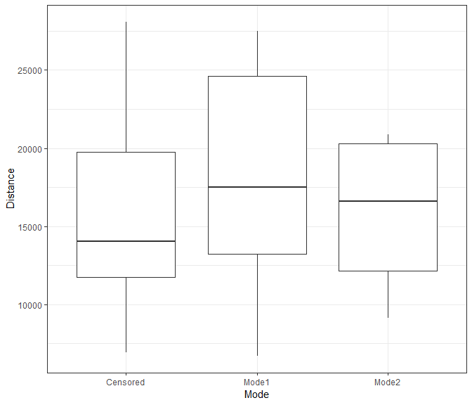

Figure 2: Boxplots for different modes.

```r
# Comparison of failure modes:
ggplot(data = shock, aes(x = Mode, y = Distance)) +
  geom_boxplot() +
  theme_bw()
```

## Estimation of Failure Probabilities with Package `weibulltools`

For reasons of simplicity we will ignore the differences between the failure modes *Mode1* and *Mode2* which are shown in *Figure 2*. Thus, we will act as there is only one mechanism of damage.

First, we are interested in how censored observations influence the estimation of failure probabilities in comparison to the case where only failed units are considered. In the latter case we will use the function `mr_method()`. To deal with survived and failed units we will use function `johnson_method()`.

```r
# First case where only failed units are taken into account:
df_mr <- mr_method(id = shock$id[shock$Censor == 1],
                   x = shock$Distance[shock$Censor == 1],
                   event = shock$Censor[shock$Censor == 1])
knitr::kable(df_mr, format = "html", row.names = FALSE, align = "c",
             caption = "Table 1: Failure probabilities using failed items.")
```

Table 1: Failure probabilities using failed items.

| id | characteristic | status | rank | prob |
| --- | --- | --- | --- | --- |
| a | 6700 | 1 | 1 | 0.0614035 |
| Y | 9120 | 1 | 2 | 0.1491228 |
| X | 12200 | 1 | 3 | 0.2368421 |
| E | 13150 | 1 | 4 | 0.3245614 |
| H | 14300 | 1 | 5 | 0.4122807 |
| W | 17520 | 1 | 6 | 0.5000000 |
| F | 20100 | 1 | 7 | 0.5877193 |
| q | 20900 | 1 | 8 | 0.6754386 |
| y | 22700 | 1 | 9 | 0.7631579 |
| J | 26510 | 1 | 10 | 0.8508772 |
| g | 27490 | 1 | 11 | 0.9385965 |

```r
# Second case where both, survived and failed units are considered:
df_john <- johnson_method(id = shock$id, x = shock$Distance, event = shock$Censor)
knitr::kable(df_john, format = "html", row.names = FALSE, align = "c",
             caption = "Table 2: Failure probabilities using all items.")
```

Table 2: Failure probabilities using all items.

| id | characteristic | status | rank | prob |
| --- | --- | --- | --- | --- |
| a | 6700 | 1 | 1.000000 | 0.0182292 |
| z | 6950 | 0 | NA | NA |
| d | 7820 | 0 | NA | NA |
| C | 8790 | 0 | NA | NA |
| Y | 9120 | 1 | 2.085714 | 0.0465030 |
| w | 9660 | 0 | NA | NA |
| f | 9820 | 0 | NA | NA |
| k | 11310 | 0 | NA | NA |
| h | 11690 | 0 | NA | NA |
| i | 11850 | 0 | NA | NA |
| I | 11880 | 0 | NA | NA |
| O | 12140 | 0 | NA | NA |
| X | 12200 | 1 | 3.452910 | 0.0821070 |
| V | 12870 | 0 | NA | NA |
| E | 13150 | 1 | 4.874794 | 0.1191353 |
| l | 13330 | 0 | NA | NA |
| c | 13470 | 0 | NA | NA |
| p | 14040 | 0 | NA | NA |
| H | 14300 | 1 | 6.499803 | 0.1614532 |
| W | 17520 | 1 | 8.124813 | 0.2037712 |
| u | 17540 | 0 | NA | NA |
| K | 17890 | 0 | NA | NA |
| T | 18450 | 0 | NA | NA |
| j | 18960 | 0 | NA | NA |
| r | 18980 | 0 | NA | NA |
| t | 19410 | 0 | NA | NA |
| F | 20100 | 1 | 10.499828 | 0.2656205 |
| Z | 20100 | 0 | NA | NA |
| b | 20150 | 0 | NA | NA |
| o | 20320 | 0 | NA | NA |
| q | 20900 | 1 | 13.666514 | 0.3480863 |
| y | 22700 | 1 | 16.833199 | 0.4305521 |
| G | 23490 | 0 | NA | NA |
| J | 26510 | 1 | 20.527666 | 0.5267621 |
| R | 27410 | 0 | NA | NA |
| g | 27490 | 1 | 25.145750 | 0.6470247 |
| x | 27890 | 0 | NA | NA |
| v | 28100 | 0 | NA | NA |

If we compare *Table 1* and *Table 2* we can see that survivors decrease probabilities. But this is just that what was expected since undamaged units with longer or equal operation times (here mileage) let us gain confidence in the product.

## Probability Plotting with Package `weibulltools`

The next step is to visualize the estimated probabilities in a probability plot. With function `plot_prob()` we can construct plots for several lifetime distributions. Here we want to use a Weibull grid in which the estimates, given in *Table 1* and *Table 2*, are plotted. With `plot_prob()` we can visualize the estimates of one table (for example *Table 2*). To get the estimates of the other table (here *Table 1*) in the same graph, we have to add an additional trace (`add_trace()` function of `plotly` package). As a result the obtained estimates can be compared graphically.

```r
# Weibull grid for probabilities calculated with Johnson:
weibull_grid <- plot_prob(x = df_john$characteristic, y = df_john$prob,
                          event = df_john$status, id = df_john$id,
                          distribution = "weibull",
                          title_main = "Weibull Probability Plot",
                          title_x = "Mileage in km",
                          title_y = "Probability of Failure in %",
                          title_trace = "Failures (Johnson)")

library(plotly) # Using add_trace()
# Adding a trace so that estimated probabilities of mr_method can be plotted in
# the same graph:
# Arguments inside add_trace:
#   y: Must be transformed such that quantiles of smallest extreme value distribution are plotted.
#   x: Since distribution in plot_prob is "weibull" the x axis is already on log scale.
#      Thus x can be plugged in on natural scale.
weibull_grid_both <- weibull_grid %>%
  add_trace(data = df_mr, type = "scatter", mode = "markers", x = ~characteristic,
    y = ~SPREDA::qsev(prob), name = "Failures (MR)", color = I("#006400"),
    hoverinfo = "text", text = ~paste("ID:", id,
      paste("<br>", paste0("Mileage", ":")), characteristic,
      paste("<br>", paste0("Probability", ":")), round(prob, digits = 5)))
weibull_grid_both
```

[interactive chart not shown]

Figure 3: Plotting positions in weibull grid.

*Figure 3* shows that the consideration of survivors (blue points, *Failures (Johnson)*) decreases the failure probability in comparison to the sole evaluation of failed items (green points, *Failures (MR)*).

Finally, we want to use a Log-normal probability plot to visualize the estimated failure probabilities given in *Table 2*.

```r
# Log-Normal grid for probabilities calculated with Johnson:
lognorm_grid <- plot_prob(x = df_john$characteristic, y = df_john$prob,
                          event = df_john$status, id = df_john$id,
                          distribution = "lognormal",
                          title_main = "Log-Normal Probability Plot",
                          title_x = "Mileage in km",
                          title_y = "Probability of Failure in %",
                          title_trace = "Defect Shock Absorbers")
lognorm_grid
```

[interactive chart not shown]

Figure 4: Plotting positions in log-normal grid.

On the basis of *Figure 3* and *Figure 4* we can subjectivly assess the goodness of fit of Weibull and Log-normal. It can be seen that in both grids, the plotted points roughly fall on a straight line. Hence one can say that the Weibull as well as the Log-normal are good model candidates for the `shock` data.

[^1]: Kapur, K. C.; Lamberson, L. R.: *Reliability in Engineering Design*, *New York: Wiley*, 1977, pp. 297-301
[^2]: Benard, A.; Bos-Levenbach, E. C.: *The Plotting of Observations on Probability Paper*, *Statistica Neerlandica 7 (3)*, 1953, pp. 163-173
[^3]: Meeker, W. Q.; Escobar, L. A.: *Statistical Methods for Reliability Data*, *New York, Wiley series in probability and statistics*, 1998, p. 630